# L”Lahman Baseball Dataset”

These are notes that follow the book [Analyzing Baseball Data with R](https://baseballwithr.wordpress.com/about/).

# Libraries

```r
library(tidyverse)
library(Lahman)
library(GGally)
```

# Functions

```r
get_player_id <- function(Name){
  Names <- stringr::str_split(Name, pattern = " ") %>% unlist()
  firstName <- Names[1]
  lastName <- Names[2]

  Lahman::People %>%
    filter(nameFirst == firstName, nameLast == lastName) %>%
    select(playerID) %>%
    unlist()
}
```

# Data

If you want to download the complete dataset, then go to [Sean Lahman’s Baseball Database](https://www.seanlahman.com/baseball-archive/statistics). Otherwise, you can use the `Lahman` package in R without the need to download any files.

## Available Tables

```r
Lahman::LahmanData
```

| file | class | nobs | nvar | title |
| --- | --- | --- | --- | --- |
| AllstarFull | data.frame | 5454 | 8 | AllstarFull table |
| Appearances | data.frame | 110423 | 21 | Appearances table |
| AwardsManagers | data.frame | 179 | 6 | AwardsManagers table |
| AwardsPlayers | data.frame | 6531 | 6 | AwardsPlayers table |
| AwardsShareManagers | data.frame | 425 | 7 | AwardsShareManagers table |
| AwardsSharePlayers | data.frame | 6879 | 7 | AwardsSharePlayers table |
| Batting | data.frame | 110495 | 22 | Batting table |
| BattingPost | data.frame | 15879 | 22 | BattingPost table |
| CollegePlaying | data.frame | 17350 | 3 | CollegePlaying table |
| Fielding | data.frame | 147080 | 18 | Fielding table |

[output cut: 17 more lines]

The primary table we will need to get player information is the `People` table. A full explanation can be found the `README.txt` file in the Lahman Database site.

```r
data(People)
People %>%
  head(1)
```

|  | playerID | birthYear | birthMonth | birthDay | birthCountry | birthState | birthCity | deathYear | deathMonth | deathDay | deathCountry | deathState | deathCity | nameFirst | nameLast | nameGiven | weight | height | bats | throws | debut | finalGame | retroID | bbrefID | deathDate | birthDate |
| --- | --- | --- | --- | --- | --- | --- | --- | --- | --- | --- | --- | --- | --- | --- | --- | --- | --- | --- | --- | --- | --- | --- | --- | --- | --- | --- |
| 1 | aardsda01 | 1981 | 12 | 27 | USA | CO | Denver | NA | NA | NA | NA | NA | NA | David | Aardsma | David Allan | 215 | 75 | R | R | 2004-04-06 | 2015-08-23 | aardd001 | aardsda01 |  | 1981-12-27 |

## Small Example

There are an assortment of analyses you can conduct with this data. The example below shows the HR trajectory of the top four HR hitters in MLB history.

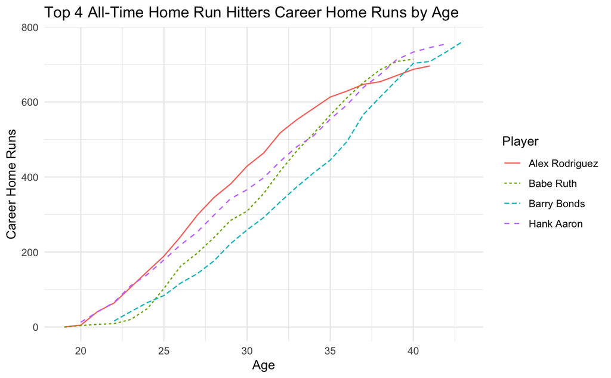

```r
players <- c("Babe Ruth", "Hank Aaron", "Barry Bonds", "Alex Rodriguez")
player_ids <- map_chr(players, get_player_id)

Lahman::Batting %>%
  filter(playerID %in% player_ids) %>%
  left_join(Lahman::People, by="playerID") %>%
  group_by(playerID) %>%
  mutate(Age = yearID - birthYear,
         Player = paste(nameFirst, nameLast),
         cum_HR = cumsum(HR)) %>%
  ggplot(aes(x = Age, y = cum_HR)) +
  geom_line(aes(linetype = Player, color = Player)) +
  scale_y_continuous("Career Home Runs") +
  ggtitle("Top 4 All-Time Home Run Hitters Career Home Runs by Age") +
  theme_minimal()
```

## Questions

### What is the average number of home runs recorded in each decade?

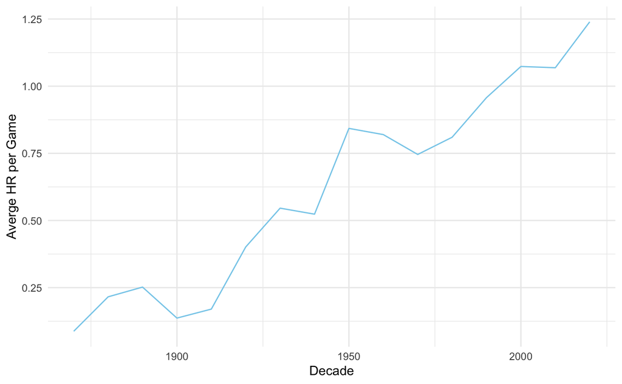

```r
avg_HR <- Lahman::Teams %>%
  mutate(decade = floor((yearID/10)) * 10) %>%
  select(decade, G, HR) %>%
  group_by(decade) %>%
  summarise(totalGames = sum(G),
            totalHR = sum(HR)) %>%
  ungroup() %>%
  mutate(averageHR = totalHR/totalGames)

avg_HR %>%
  ggplot(aes(x = decade, y = averageHR)) +
  geom_line(color = "skyblue") +
  xlab("Decade") +
  scale_y_continuous("Averge HR per Game") +
  theme_minimal()
```

### Does the rate of strikeouts show any correlation with the rate of home runs?

From a view of the pairs, plot the data suggests there is a correlation between the rate of strikeouts and the rate of home runs.

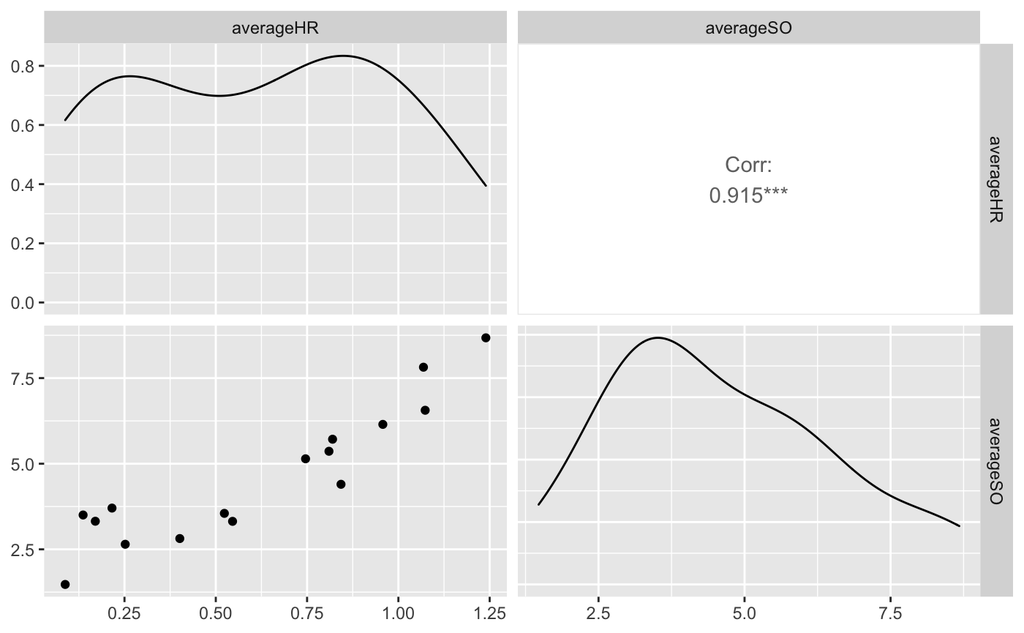

```r
so_vs_hr <- Lahman::Teams %>%
  mutate(decade = floor((yearID/10)) * 10) %>%
  select(decade, G, SO, HR) %>%
  group_by(decade) %>%
  summarise(totalGames = sum(G),
            totalHR = sum(HR),
            totalSO = sum(SO, na.rm = TRUE)) %>%
  ungroup() %>%
  mutate(averageHR = totalHR/totalGames,
         averageSO = totalSO/totalGames)

ggpairs(so_vs_hr,
        columns = 5:6)
```

### What effect has the introduction of the Designated Hitter (DH) in the American League had in the difference in run scoring between the American and National Leagues?

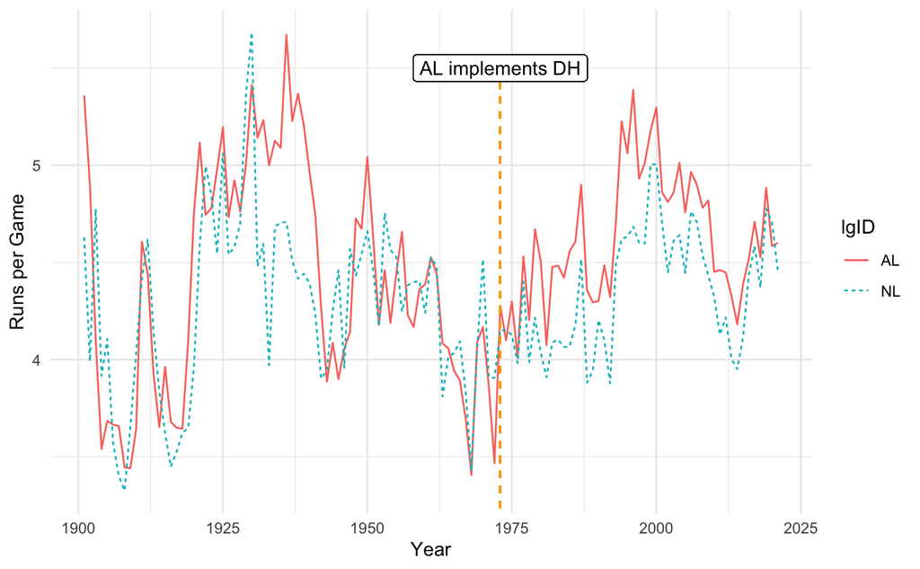

```r
RPG <- Teams %>%
  filter(yearID >= 1901, lgID %in% c("AL", "NL")) %>%
  select(yearID, lgID, G, R) %>%
  group_by(yearID, lgID) %>%
  summarise(totalRuns = sum(R),
            totalGames = sum(G)) %>%
  ungroup() %>%
  mutate(rpg = totalRuns/totalGames)

ggplot(RPG, aes(x = yearID, y = rpg)) +
  geom_line(aes(linetype = lgID, color = lgID)) +
  geom_segment(
    x = 1973, xend = 1973,
    y = 0, yend = 5.5,
    color = "orange",
    lty = 2
  ) +
  xlab("Year") +
  scale_y_continuous("Runs per Game") +
  geom_label(
    x = 1973, y = 5.5,
    label = "AL implements DH"
  ) +
  theme_minimal()
```

### How does the percentage of games completed by the starting pitcher from 2000 to 2010 compare to the percentage of games 100 years before?

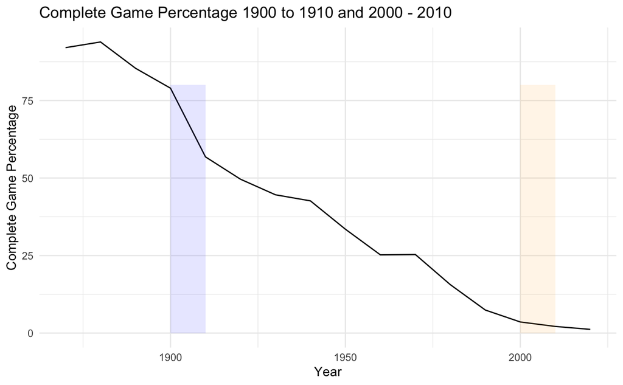

```r
pct_complete <- Pitching %>%
  mutate(decade = floor(yearID/10) * 10) %>%
  select(decade, GS, CG) %>%
  group_by(decade) %>%
  summarise(totalGamesStarted = sum(GS),
            totalCompleteGames = sum(CG)) %>%
  ungroup() %>%
  mutate(pctCG = round((totalCompleteGames / totalGamesStarted) * 100, 2))

ggplot(pct_complete, aes(x = decade, y = pctCG)) +
  geom_line() +
  annotate("rect", xmin = 1900, xmax = 1910, ymin = 0, ymax = 80,
           alpha = .1,fill = "blue") +
  annotate("rect", xmin = 2000, xmax = 2010, ymin = 0, ymax = 80,
           alpha = .1,fill = "orange") +
  xlab("Year") +
  scale_y_continuous("Complete Game Percentage") +
  ggtitle("Complete Game Percentage 1900 to 1910 and 2000 - 2010") +
  theme_minimal()
```